# MATP-4400 Final Project Notebook (2021)

Predicting Biodegradability Challenge

Jared Gridley

March 2021

# Team Information

- http://codalab.idea.rpi.edu/competitions/37 (RPI VPN - faster)

# BACKGROUND

## Chems-R-Us Task

The European REACH regulation requires information on ready biodegradation, which is a screening test to assess the biodegradability of chemicals. At the same time REACH encourages the use of alternatives to animal testing.

Our contract is to build a classification model to predict ready biodegradation of chemicals and to predict the classification of 400 newly-developed molecules. This will help Chems-R-Us to design new materials with desired biodegradation properties more quickly and for lower cost.

## Chems-R-Us Challenge Objective

The Chems-R-Us Challenge consists of two problems:

- **Binary classification:** Each data row is labeled **-1** or **1**. We must train a predictive model on the train dataset to be able to find (as best we can) the labels of the test dataset.
- **Feature selection:** Scattered among the 168 features there are *fake features*. These are randomly generated variables which don’t help predicting the class. The goal of this problem is to classify features between *fake* **0** and *real* **1**.

## Chems-R-Us Training & Testing Data

- Experimental values of 1055 chemicals were collected.
- The training dataset consists of these 1055 chemicals; whether they were readily biodegradable (1= yes , -1 = no); and 168 molecular descriptors.
- Molecules and Molecular descriptors are proprietary. No details are provided except *cryptic names* in column headers
- A testing set of 400 molecules with unknown biodegradability is provided

# Chems-R-Us BASELINE Logistic Regression (LR) Methodology

### Reading the Data

```r
knitr::opts_chunk$set(cache = T)

# Set the correct default repository
r = getOption("repos")
r["CRAN"] = "http://cran.rstudio.com"
options(repos = r)


# These will install required packages if they are not already installed
if (!require("ggplot2")) {
   install.packages("ggplot2", dependencies = TRUE)
   library(ggplot2)
}
if (!require("knitr")) {
   install.packages("knitr", dependencies = TRUE)
   library(knitr)
}
if (!require("xtable")) {
   install.packages("xtable", dependencies = TRUE)
   library(xtable)
}
if (!require("pander")) {
   install.packages("pander", dependencies = TRUE)
   library(pander)
}

if (!require("devtools")) {
  install.packages("devtools",dependencies = TRUE )
  library(devtools)
}

if (!require("usethis")) {
  install.packages("usethis" )
  library(usethis)
}

if (!require("e1071")) {
 install.packages("e1071" )
  library(e1071)
}

if (!require("pROC")){
  install.packages("pROC")
   library(pROC)
}

if (!require("dplyr")) {
   install.packages("dplyr", dependencies = TRUE)
   library(dplyr)
}

if (!require("tidyverse")) {
   install.packages("tidyverse", dependencies = TRUE)
   library(tidyverse)
}

if (!require("caret")) {
   install.packages("caret", dependencies = TRUE)
   library(caret)
}

if (!require("mlbench")) {
   install.packages("mlbench")
   library(mlbench)
}

if (!require("randomForest")) {
   install.packages("randomForest")
   library(randomForest)
}

if(!require("glmnet")) {
   install.packages("glmnet")
   library(glmnet)
}

if(!require("gbm")){
   install.packages("gbm")
   library(gbm)
}
if(!require("MASS")){
   install.packages("MASS")
   library(MASS)
}
knitr::opts_chunk$set(echo = TRUE)
```

### Preparing the Data: Create Training and Validation datasets

We split the data into **90% train** and **10% validation** datasets.

```r
# Prepare biodegradability data
#get feature names
featurenames <- read.csv("~/MATP-4400/data/chems_feat.name.csv",
                         header=FALSE,
                         colClasses = "character")
# get training data and rename with feature names
cdata.df <-read.csv("~/MATP-4400/data/chems_train.data.csv",
                    header=FALSE)
colnames(cdata.df) <- featurenames$V1

# get external testing data and rename with feature names
tdata.df <-read.csv("~/MATP-4400/data/chems_test.data.csv",
                    header=FALSE)

colnames(tdata.df) <- featurenames$V1

class <- read.csv("~/MATP-4400/data/chems_train.solution.csv",
                  header=FALSE,
                  colClasses = "factor")

class <- class$V1
```

We then standardize all variables to a *common scale*, since we don’t have domain knowledge and LR assumes independent and identically distributed (IID) Gaussian features. This avoids LR unwittingly prioritizing certain features simply because their scale is larger.

```r
#ss will be the number of data points in the training set
n <- nrow(cdata.df)
ss <- ceiling(n*0.90)
# Set random seed for reproducibility
set.seed(200)
train.perm <- sample(1:n,ss)
#Split training and validation data
train <- cdata.df %>% slice(train.perm)
validation <- cdata.df %>% slice(-train.perm)

train_raw <- train
validation_raw <- validation
```

### Fitting Logistic Regression

```r
# Initialize the scaler on the training data
scaler <- preProcess(train, method = "scale")
# Normalize training data
train <- predict(scaler, train)
# Normalize validation data
validation <- predict(scaler, validation)
# Normalize testing data
test <- predict(scaler, tdata.df)
# Split the output classes
classtrain <- class[train.perm]
classval <-class[-train.perm]
```

### Calculate LR Balanced Accuracy on the Validation dataset

To assess the model’s performance, we built a **confusion matrix** of the validation outputs to get mis-classification rates and the balanced accuracy. We convert the probability estimates to class outputs and define the matrix.

```r
# This is a group of helper functions meant to avoid repetitiveness and shorten presentation output

prob_to_class <- function(ranking_lr) {
   # This helper function converts LR probability outputs into 1 and -1 classes
   temp <- ranking_lr > 0.5
   temp[temp==TRUE] <- 1
   temp[temp==FALSE] <- -1
   return(as.factor(temp))
}

sensitivity_from_confmat <- function(confmat) {
   # This helper returns the sensitivity given a confusion matrix
   return(confmat[1,1]/(confmat[1,1]+confmat[1,2]))
}

specificity_from_confmat <- function(confmat) {
   # This helper returns the specificity given a confusion matrix
   return(confmat[2,2]/(confmat[2,1]+confmat[2,2]))
}
```

### Calculate LR Balanced Accuracy on the Validation dataset (2)

Given the confusion matrix $M$, we can find the balanced accuracy using the formula
$$\begin{align*}
Sensitivity &= \frac{M_{1,1}}{M_{1,1} + M_{1,2}} = \frac{TruePos}{TruePos + FalseNeg} \\
Specificity &= \frac{M_{2,2}}{M_{2,1} + M_{2,2}} = \frac{TrueNeg}{TrueNeg + FalsePos}\\
BalancedAccuracy &= \frac{1}{2}\left(Sensitivity + Specificity\right)
\end{align*}$$

```r
# This function converts PROBABILITIES to 1 and -1 CLASSES
classval_lr <- prob_to_class(ranking_lr.val)
# Calculate confusion matrix  to see balanced accuracy
confusion.matrix <- table(classval,classval_lr)
kable(confusion.matrix, type="html",digits = 2,
      caption="Actual versus Predicted Class (Validation)")
```

Actual versus Predicted Class (Validation)

|  | -1 | 1 |
| --- | --- | --- |
| -1 | 63 | 10 |
| 1 | 6 | 26 |

### Feature Selection: Choosing Statistically Significant Regression Variables

Given our use of Logistic Regression as a classification model, one simple way to perform feature selection is to select features with *statistically significant* coefficients in the LR model.

```r
# True Positive Rate or Sensitivity
Sensitivity <- sensitivity_from_confmat(confusion.matrix)
# True Negative Rate or Specificity
Specificity <- specificity_from_confmat(confusion.matrix)
BalancedAccuracy <- (Sensitivity+Specificity)/2
```

### Fit Logistic Regression with Feature Selection

```r
# Get data frame with coefficient data excluding intercept
coefficients.df <- as.data.frame(summary(lrfit)$coeff) %>%
   slice(2:n())
# Boolean vector with TRUE corresponding to significant variables
significant.variables <- coefficients.df %>%
   dplyr::select(last_col()) <= 0.2
# Keep only statistically significant features
train.fs <- train %>% select_if(significant.variables)
train.fs.df <- cbind(train.fs, classtrain)
```

### LR Validation Balanced Accuracy with Feature Selection

To assess the model’s performance with feature selection, we build a confusion matrix and compute the balanced accuracy exactly as before.

The LR model with feature selection results in a validation balanced accuracy of 0.8446062. Since this is higher than the balanced accuracy of LR with all features, it’s plausible our feature selection might be doing an OK job at finding the true features.

## Computing ROC Curves for LR & LR with Feature Selection

Here we compute the ROC curves for LR and LR with feature selection. We can see that their performance is very comparable.

Here is a video explaining AUC from Statquest: https://www.youtube.com/watch?v=C4N3_XJJ-jU

- **Sensitivity** (also called the *true positive rate* or the *recall*) measures the proportion of actual positives that are correctly identified as such (e.g., the percentage of passengers that survived people who are correctly identified as having survived). *It is the same as the Class 1 accuracy.*
- **Specificity** (also called the *true negative rate*) measures the proportion of actual negatives that are correctly identified as such (e.g., the percentage of patients who died who are correctly identified as not having died). *It is the same as the Class -1 accuracy.*

### ROC Curves

```r
classval_lr.fs <- prob_to_class(ranking_lr.fs.val)
confusion.matrix <- table(classval,classval_lr.fs)
Sensitivity <- sensitivity_from_confmat(confusion.matrix)
Specificity <- specificity_from_confmat(confusion.matrix)
BalancedAccuracy <- (Sensitivity+Specificity)/2
kable(confusion.matrix, type="html",digits = 2,
      caption="Actual versus Predicted Class (Validation)")
```

Actual versus Predicted Class (Validation)

|  | -1 | 1 |
| --- | --- | --- |
| -1 | 64 | 9 |
| 1 | 6 | 26 |

### Interpreting the ROC Results

The validation results show that LR with feature selection produces slightly better generalizations (accuracy on the validation set) results than our original model using all the variables.

#Feature Selection #Feature Selection 1: Removing redundant and unimportant features

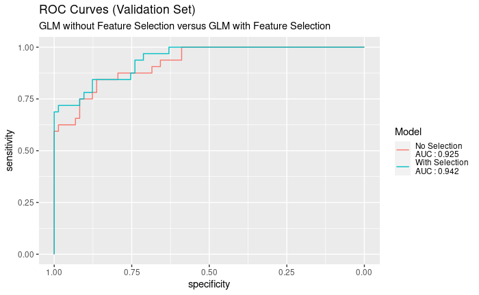

```r
roc.data <- data.frame("Class" = classval,
                       "No Selection" = ranking_lr.val,
                       "With Selection" = ranking_lr.fs.val)
roc.list <- roc(Class ~.,
                data = roc.data)
no.selection.auc <- round(auc(Class ~ No.Selection, data = roc.data), digits = 3)
with.selection.auc <- round(auc(Class ~ With.Selection, data = roc.data), digits = 3)
roc_plot <- ggroc(roc.list) +
   ggtitle("ROC Curves (Validation Set)", subtitle = "GLM without Feature Selection versus GLM with Feature Selection") +
   scale_color_discrete(name = "Model",
                        labels = c(paste("No Selection\nAUC :", no.selection.auc), paste("With Selection\nAUC :", with.selection.auc)))
roc_plot
```

```r
train_raw.mc <- as.data.frame(scale(train_raw, scale = FALSE))
train_raw.df <- cbind(train_raw, classtrain)

#Searching for Redundant features
correlation_matrix <- cor(train_raw);

# Can try varying the cutoff, try 0.5 and 0.75
highlyCorrelated <- findCorrelation(correlation_matrix, cutoff = 0.75)
#These are the features we want to remove
print(highlyCorrelated)
```

```
 [1]  87  94 120 127 148 153   1  14  72  90  56  85  68
```

```r
train_noRedun <- train_raw.df[-c(highlyCorrelated)]
val_noRedun <- validation_raw[-c(highlyCorrelated)]


#Now we look for the most important features using a Learning Vector Quantization
control <- trainControl(method = "repeatedcv", number = 10, repeats = 3)
#training the LVQ model
lvqmodel <- train(classtrain~., data = train_noRedun, method = "lvq", preProcess = "scale", trControl = control)
importance <- varImp(lvqmodel, scale = FALSE)
```

We can see that the first method of feature selection chose 47 of the original features as important.

#Feature Selection 2: Recursive Feature Elimination

```r
imp.m <- importance$importance
ImpFeat <- row.names(imp.m[imp.m[,1]>= 0.52, ])
train_ImpFeat <- cbind(train_noRedun[c(ImpFeat)], classtrain)
print(importance)
```

```
ROC curve variable importance

  only 20 most important variables shown (out of 155)
```

|  | Importance |
| --- | --- |
| X160 | 0.8364838 |
| X85 | 0.7906683 |
| X138 | 0.7675596 |
| X37 | 0.6946934 |
| X59 | 0.6944173 |
| X27 | 0.6708920 |
| X115 | 0.6570130 |
| X130 | 0.6499083 |
| X29 | 0.6331154 |
| X3 | 0.6267404 |

[output cut: 10 more lines]

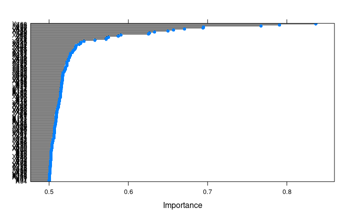

```r
plot(importance)
```

#Feature Selection Method 3: LASSO Regression LASSO Regression, in theory, will help to sort out data that isn’t independant on its own. If a certain feature is highly correlated with another, then they will be considered highly correlated and both will not be needed. This is similar to the redundant information extraction abover, however this method is said to work better that redundancy testing.

```r
control <- rfeControl(functions=rfFuncs, method = "cv", number=10)

results <- rfe(train_noRedun[,1:155], train_noRedun[,156], sizes = c(1:8), rfeControl = control)

train.rfe = cbind(train_noRedun[c("X160", "X85", "X138", "X115")], classtrain)
print(results)
```

```
Recursive feature selection

Outer resampling method: Cross-Validated (10 fold)

Resampling performance over subset size:
```

|  | Variables | Accuracy | Kappa | AccuracySD | KappaSD | Selected |
| --- | --- | --- | --- | --- | --- | --- |
| 1 | 1 | 0.9968 | 0.9929 | 0.007105 | 0.01588 |  |
| 2 | 2 | 0.9937 | 0.9860 | 0.005427 | 0.01204 |  |
| 3 | 3 | 0.9853 | 0.9672 | 0.012273 | 0.02751 |  |
| 4 | 4 | 0.9969 | 0.9930 | 0.005067 | 0.01133 | * |
| 5 | 5 | 0.9927 | 0.9836 | 0.008628 | 0.01934 |  |
| 6 | 6 | 0.9874 | 0.9718 | 0.010834 | 0.02425 |  |
| 7 | 7 | 0.9853 | 0.9670 | 0.012277 | 0.02760 |  |
| 8 | 8 | 0.9832 | 0.9622 | 0.014152 | 0.03181 |  |
| 9 | 155 | 0.9506 | 0.8864 | 0.012137 | 0.02884 |  |

```
The top 4 variables (out of 4):
   X160, X85, X138, X115
```

```r
predictors(results)
```

```
[1] "X160" "X85"  "X138" "X115"
```

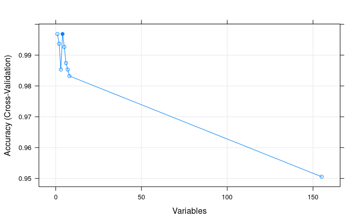

```r
plot(results, type = c("g", "o"))
```

```r
y <- apply( as.matrix(classtrain), 2, as.numeric)
x <- apply(as.matrix(train_raw) ,2, as.numeric)

cv_model <- cv.glmnet(x, y, alpha = 1)

best.lambda <- cv_model$lambda.min
best.lambda
```

```
[1] 0.03864164
```

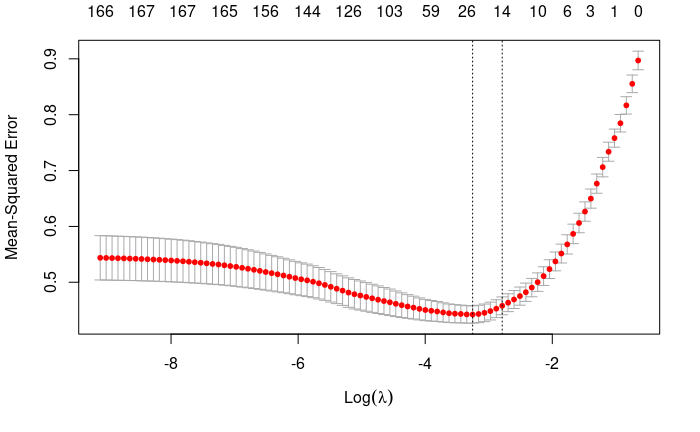

```r
plot(cv_model)
```

So we can see that there are many irrelevent features scattered in the data (as indicated by the period or zeros). The period means that those features had regressed to zero and they feature extraction algorithm believes them to be irrelevant. So we can extract the features that this model considers important and use them to test with our classification algorithms.

```r
lasso_model <- glmnet(x, y, alpha = 1, lambda = best.lambda)

lasso.results <- coef(lasso_model)
lasso.results[1:32,]
```

```
  (Intercept)            X0            X1            X2            X3            X4            X5            X6            X7            X8            X9
 2.7057295281  0.0000000000  0.0000000000  0.0000000000  0.0000000000  0.0690647785 -0.0008198592 -0.0144772510  0.0000000000  0.0000000000  0.0000000000
          X10           X11           X12           X13           X14           X15           X16           X17           X18           X19           X20
 0.0000000000  0.0000000000  0.0000000000  0.0000000000  0.0000000000  0.0000000000  0.0000000000  0.0000000000  0.0680927344  0.0000000000  0.0000000000
          X21           X22           X23           X24           X25           X26           X27           X28           X29           X30
 0.1574222606  0.0000000000  0.0000000000  0.0000000000  0.0000000000  0.0000000000 -0.0137916232  0.0000000000  0.0000000000  0.0000000000
```

#Classification Algorithm 1: Bayes Theorum Bayes theorum is supposed to work well with less training data (<10000 samples) however it assumes that each of the features is independent of each other. Which may not work out as well with chemical features, like boiling point and bonding type would be very closely related and in theory not independent. Also, I am expecting that having unnecessary features will hinder Bayes’ success so I will need a good feature selection algorithms to pair with it.

First, I will look at it with all of the features and then apply the reduced feature models

```r
lasso.ft <- lasso.results@Dimnames[[1]][lasso.results[,1] != 0][-1]

train.lasso <- cbind(train_raw[c(all_of(lasso.ft))], classtrain)
val.lasso <- cbind(validation_raw[c(all_of(lasso.ft))], classval)
```

# Classification Algorithm 2: Linear Discriminant Analysis

```r
train_raw.df <- cbind(train_raw, as.factor(classtrain))
val_raw.df <- cbind(validation_raw, classval)

#Start with Bayes theorum on all of the data
Bayes_allFeat <- naiveBayes(classtrain~., data = train_raw.df)
train.bayesAllFeat.pred <- predict(Bayes_allFeat, train_raw.df)
val.bayesAllFeat.pred <- predict(Bayes_allFeat, val_raw.df)

confusion.matrix.all <- table(classval, val.bayesAllFeat.pred)
confusion.matrix.all
```

```
        val.bayesAllFeat.pred
classval -1  1
      -1 48 25
      1   0 32
```

```r
#Bayes Theorum with Feature Selection 1 (redundancy/importance)
val_Imp.df <- cbind(validation_raw[c(ImpFeat)], classval)
Bayes_Imp <- naiveBayes(classtrain~., data =train_ImpFeat)

train.bayesImp.pred <- predict(Bayes_Imp, train_ImpFeat)
val.bayesImp.pred <- predict(Bayes_Imp, val_Imp.df)

confusion.matrix.Imp <- table(classval, val.bayesImp.pred)
confusion.matrix.Imp
```

```
        val.bayesImp.pred
classval -1  1
      -1 48 25
      1   1 31
```

```r
#Bayes theorem on Recursive Feature Elimination
val_rfe.df <- cbind(validation_raw[c("X160", "X85", "X138", "X115")], classval)
Bayes_rfe <- naiveBayes(classtrain~., data = train.rfe)

train.bayesrfe.pred <- predict(Bayes_rfe, train.rfe)
val.bayesrfe.pred <- predict(Bayes_rfe, val_Imp.df)

confusion.matrix.rfe <- table(classval, val.bayesrfe.pred)
confusion.matrix.rfe
```

```
        val.bayesrfe.pred
classval -1  1
      -1 58 15
      1   6 26
```

```r
#Bayed Theorum with LASSO
Bayes_lasso <- naiveBayes(classtrain~., data = train.lasso)

train.bayeslasso.pred <- predict(Bayes_lasso, train.lasso)
val.bayeslasso.pred <- predict(Bayes_lasso, val.lasso)

confusion.matrix.lasso <- table(classval, val.bayeslasso.pred)
confusion.matrix.lasso
```

```
        val.bayeslasso.pred
classval -1  1
      -1 49 24
      1   2 30
```

#Classification Algorithm 3 - Logistic Regression (Revisited) Logistic Regression and a relatively common but well tested method. It works well on a large range of datasets and thus, with the proper feature selection, could be a great option.

```r
#LDA will not run without some feature reduction because of the noise in the data

#LDA with Feature Selection 1  (redundancy/importance)
test.Imp <- test[c(ImpFeat)]
lda.fit.imp <- lda(classtrain~., train_ImpFeat, prior = c(1,1)/2)

train.lda.pred <- predict(lda.fit.imp,train_ImpFeat)
val.lda.pred <- predict(lda.fit.imp, val_Imp.df, type="response")

ranking_lda.Imp.val <- val.lda.pred$posterior[,2]

confusion.matrix.ldaI <- table(classval,val.lda.pred$class)
Sensitivity <- sensitivity_from_confmat(confusion.matrix.ldaI)
Specificity <- specificity_from_confmat(confusion.matrix.ldaI)
BalancedAccuracy.lda.I <- (Sensitivity+Specificity)/2
kable(confusion.matrix.ldaI, type="html",digits = 2,
      caption="Feature Selection 1 with LDA (Validation)")
```

Feature Selection 1 with LDA (Validation)

|  | -1 | 1 |
| --- | --- | --- |
| -1 | 69 | 4 |
| 1 | 4 | 28 |

```r
#LDA with Feature Selection 2 (Recursive Feature Elimination)
lda.fit.rfe <- lda(classtrain~., train.rfe, prior = c(1,1)/2)

train.rfe.pred <- predict(lda.fit.rfe, train.rfe)$class
val.rfe.pred <- predict(lda.fit.rfe, val_rfe.df, type="response")

ranking_lda.rfe.val <- val.rfe.pred$posterior[,2]
conf.matrix.rfe <- table(classval, val.rfe.pred$class)
Sensitivity.rfe <- sensitivity_from_confmat(conf.matrix.rfe)
Specificity.rfe <- specificity_from_confmat(conf.matrix.rfe)
BalancedAccuracy.rfe <- (Sensitivity.rfe +Specificity.rfe)/2
kable(conf.matrix.rfe, type="html",digits = 2,
      caption="Feature Selection 2 with LDA (Validation)")
```

Feature Selection 2 with LDA (Validation)

|  | -1 | 1 |
| --- | --- | --- |
| -1 | 60 | 13 |
| 1 | 5 | 27 |

```r
#LDA with Feature Selection 3 (LASSO Regression)
lda.fit.lasso <- lda(classtrain~., train.lasso, prior = c(1,1)/2)

train.lasso.pred <- predict(lda.fit.lasso, train.lasso)$class
val.lasso.pred <- predict(lda.fit.lasso, val.lasso, type="response")


ranking_lda.las.val <- val.lasso.pred$posterior[,2]
conf.matrix.las <- table(classval, val.lasso.pred$class)
Sensitivity.las <- sensitivity_from_confmat(conf.matrix.las)
Specificity.las <- specificity_from_confmat(conf.matrix.las)
BalancedAccuracy.las <- (Sensitivity.las +Specificity.las)/2
kable(conf.matrix.las, type="html",digits = 2,
      caption="Feature Selection 3 with LDA (Validation)")
```

Feature Selection 3 with LDA (Validation)

|  | -1 | 1 |
| --- | --- | --- |
| -1 | 69 | 4 |
| 1 | 5 | 27 |

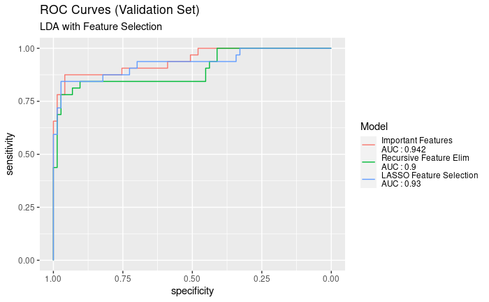

```r
roc.data <- data.frame("Class" = classval,
                       "Important Data" = ranking_lda.Imp.val,
                       "RFE" = ranking_lda.rfe.val,
                       "LASSO" = ranking_lda.las.val)
roc.list <- roc(Class ~.,
                data = roc.data)
Important.data.auc <- round(auc(Class ~ Important.Data, data = roc.data), digits = 3)
RFE.data.auc <- round(auc(Class ~ RFE, data = roc.data), digits = 3)
LASSO.data.auc <- round(auc(Class ~ LASSO, data = roc.data), digits = 3)
roc_plot <- ggroc(roc.list) +
   ggtitle("ROC Curves (Validation Set)", subtitle = "LDA with Feature Selection") +
   scale_color_discrete(name = "Model",
                        labels = c(paste("Important Features\nAUC :", Important.data.auc), paste("Recursive Feature Elim\nAUC :", RFE.data.auc), paste("LASSO Feature Selection\nAUC :", LASSO.data.auc)))
roc_plot
```

```r
LDA_results <- data.frame(c(BalancedAccuracy.lda.I, Important.data.auc), c(BalancedAccuracy.rfe, RFE.data.auc), c(BalancedAccuracy.las, LASSO.data.auc))
```

Once Again, we can see that the Important Features selection method produced the best results and similarly, the Recursive feature elimination method, while still lagging behind, did fairly well, indicating that those 4 features make up the majority of the classification importance.

#Final Analysis So far we have the best performing curves from each model, LDA and Logistic Regession. To better visually compare them, we can plot the auc score for just the two highest performing combinations.

```r
# Feature Reduction 1 : Importance
lrfit.imp <- glm(classtrain~., data=train_ImpFeat,
             family = "binomial")

ranking_lr.train.Imp <- predict(lrfit.imp,train_ImpFeat, type="response")
ranking_lr.val.Imp <- predict(lrfit.imp,val_Imp.df,type="response")

classval_lr.Imp <- prob_to_class(ranking_lr.val.Imp)
# Calculate confusion matrix  to see balanced accuracy
confusion.matrix.lrImp <- table(classval,classval_lr.Imp)
Sensitivity.lr.Imp <- sensitivity_from_confmat(confusion.matrix.lrImp)
Specificity.lr.Imp <- specificity_from_confmat(confusion.matrix.lrImp)
BalancedAccuracy.lr.Imp <- (Sensitivity.lr.Imp + Specificity.lr.Imp)/2
kable(confusion.matrix.lrImp, type="html",digits = 2,
      caption="Feature Importance with LR (Validation)")
```

Feature Importance with LR (Validation)

|  | -1 | 1 |
| --- | --- | --- |
| -1 | 71 | 2 |
| 1 | 6 | 26 |

```r
# Recursive Feature Elimination: Feature Reduction 2
lrfit.rfe <- glm(classtrain~., data=train.rfe,
             family = "binomial")

ranking_lr.train.rfe <- predict(lrfit.rfe,train.rfe, type="response")
ranking_lr.val.rfe <- predict(lrfit.rfe,val_rfe.df,type="response")

classval_lr.rfe <- prob_to_class(ranking_lr.val.rfe)
# Calculate confusion matrix  to see balanced accuracy
confusion.matrix.lr.rfe <- table(classval,classval_lr.rfe)
Sensitivity.lr.rfe <- sensitivity_from_confmat(confusion.matrix.lr.rfe)
Specificity.lr.rfe <- specificity_from_confmat(confusion.matrix.lr.rfe)
BalancedAccuracy.lr.rfe <- (Sensitivity.lr.rfe + Specificity.lr.rfe)/2
kable(confusion.matrix.lr.rfe, type="html",digits = 2,
      caption="Feature Importance with LR (Validation)")
```

Feature Importance with LR (Validation)

|  | -1 | 1 |
| --- | --- | --- |
| -1 | 67 | 6 |
| 1 | 7 | 25 |

```r
# Feature Reduction 3 : LASSO Regression
lrfit.lasso <- glm(classtrain~., data=train.lasso,
             family = "binomial")

ranking_lr.train.lasso <- predict(lrfit.lasso,train.lasso, type="response")
ranking_lr.val.lasso <- predict(lrfit.lasso,val.lasso,type="response")

classval_lr.lasso <- prob_to_class(ranking_lr.val.lasso)
# Calculate confusion matrix  to see balanced accuracy
confusion.matrix.lr.lasso <- table(classval,classval_lr.lasso)
Sensitivity.lr.lasso <- sensitivity_from_confmat(confusion.matrix.lr.lasso)
Specificity.lr.lasso <- specificity_from_confmat(confusion.matrix.lr.lasso)
BalancedAccuracy.lr.lasso <- (Sensitivity.lr.lasso + Specificity.lr.lasso)/2
kable(confusion.matrix.lr.lasso, type="html",digits = 2,
      caption="Feature Importance with LR (Validation)")
```

Feature Importance with LR (Validation)

|  | -1 | 1 |
| --- | --- | --- |
| -1 | 71 | 2 |
| 1 | 6 | 26 |

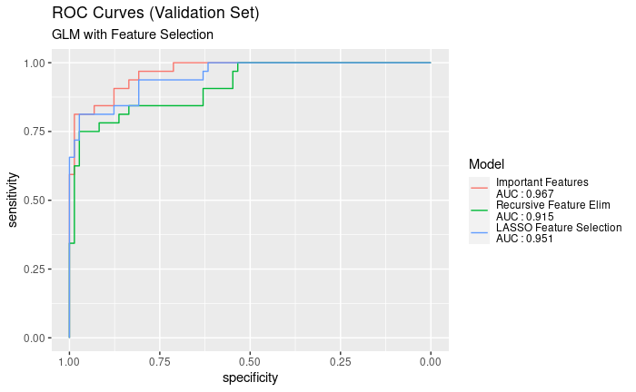

```r
roc.data <- data.frame("Class" = classval,
                       "Important Data" = ranking_lr.val.Imp,
                       "RFE" = ranking_lr.val.rfe,
                       "LASSO" = ranking_lr.val.lasso)
roc.list <- roc(Class ~.,
                data = roc.data)
Important.data.auc <- round(auc(Class ~ Important.Data, data = roc.data), digits = 3)
RFE.data.auc <- round(auc(Class ~ RFE, data = roc.data), digits = 3)
LASSO.data.auc <- round(auc(Class ~ LASSO, data = roc.data), digits = 3)
roc_plot <- ggroc(roc.list) +
   ggtitle("ROC Curves (Validation Set)", subtitle = "GLM with Feature Selection") +
   scale_color_discrete(name = "Model",
                        labels = c(paste("Important Features\nAUC :", Important.data.auc), paste("Recursive Feature Elim\nAUC :", RFE.data.auc), paste("LASSO Feature Selection\nAUC :", LASSO.data.auc)))
roc_plot
```

```r
LR_results <- data.frame(c(BalancedAccuracy.lr.Imp, Important.data.auc), c(BalancedAccuracy.lr.rfe, RFE.data.auc), c(BalancedAccuracy.lr.lasso, LASSO.data.auc))
LR_results
```

| c.BalancedAccuracy.lr.Imp..Important.data.auc. | c.BalancedAccuracy.lr.rfe..RFE.data.auc. | c.BalancedAccuracy.lr.lasso..LASSO.data.auc. |
| --- | --- | --- |
| 0.8925514 | 0.8495291 | 0.8925514 |
| 0.9670000 | 0.9150000 | 0.9510000 |

This provides an interesting result! While the AUC score for logistic regression is higher, which would typically indicate that it would have a better accuracy, the LDA actually has the higher balanced accuracy. Since, the LDA model produced a higher balanced accuracy and both are close in AUC scores, I would recommend the LDA model with the Important Features reduction method.

# Additional Analysis

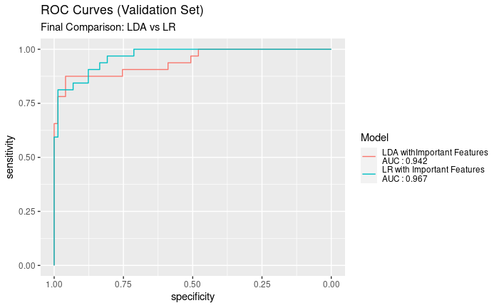

```r
roc.data <- data.frame("Class" = classval,
                       "LDA" = ranking_lda.Imp.val,
                       "LR" = ranking_lr.val.Imp)
roc.list <- roc(Class ~.,
                data = roc.data)
LDA.auc <- round(auc(Class ~ LDA, data = roc.data), digits = 3)
LR.auc <- round(auc(Class ~ LR, data = roc.data), digits = 3)
roc_plot <- ggroc(roc.list) +
   ggtitle("ROC Curves (Validation Set)", subtitle = "Final Comparison: LDA vs LR") +
   scale_color_discrete(name = "Model",
                        labels = c(paste("LDA withImportant Features\nAUC :", LDA.auc), paste("LR with Important Features\nAUC :", LR.auc)))
roc_plot
```

```r
paste("Logistic Regression Accuracy: ", BalancedAccuracy.lr.Imp)
```

```
[1] "Logistic Regression Accuracy:  0.892551369863014"
```

```r
paste("LDA Accuracy: ", BalancedAccuracy.lda.I)
```

```
[1] "LDA Accuracy:  0.910102739726027"
```

As we can see from the plots, Feature X160 is very distinguishable from the positive and negative biodegradability results. This fits with what I saw earlier when making my models. When varying the parameters for Recursive Feature Elimination, X160 often was often given as the most importnat feature. In the plot there are clear peaks where the purple dominates and a blue plateau that dominates in that range. This would thus be a very good feature to use in our analysis as it gives a clear output for most of its range. Other features, like X115 and X85 are harder to distinguish between the positive and negative biodegradability classification as there is a lot of over. Even with X138 but that feature is a little more distinguishable, with a little bit more space between the peaks.

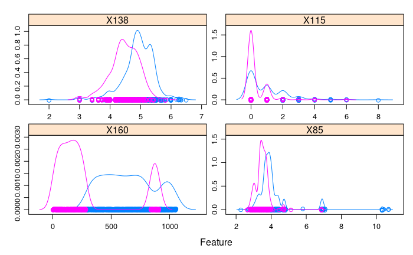

```r
rfe_data <- train.rfe

x <- rfe_data[, 1:4]
y <- rfe_data[,5]
scales <- list(x=list(relation="free"), y=list(relation="free"))
featurePlot(x=x, y=y, plot="density", scales=scales)
```

We can see that even though these were classified as the most important features, there is still a bit of redundancy. This scatterplot matrix is essentially the feature plots from above, overlayed with each other. So above, the graphs for features X85 and X115 looked similar in shape, with a different offset. With the scatterplot matrix we can see that X85 and X115 are relatively hard to distinguish, which could indicate that the recursive feature elimination method missed that. X160 on the other hand have very distint areas of red and black when overlayed with other features, indicating that it is a very good classifing feature to use.

# Challenge Results Analysis

# Conclusion

Provide the following details:

## Competition Entry: Saving & Uploading Your Predictions

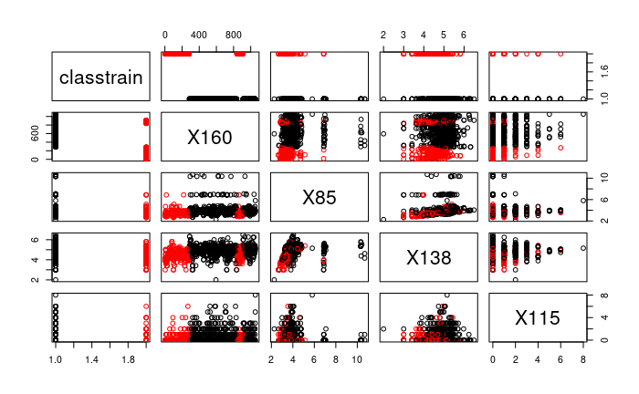

```r
pairs(classtrain~., data = rfe_data, col=rfe_data$classtrain)
```

## Storing Feature Selection Results

- Store your prediction for the features.
  - This should be **binary**, where **1 means keep the feature** and **0 means don’t keep feature**.
  - The results will be ranked by **balanced accuracy**.
- Then write the results into the CSV file named `selection.csv` (You *must* use this filename)
- NOTE: You may need to execute this code chunk (and the chunks above it) individually for `write.table()` to work.

```r
ImpFeats <- colnames(train[c(ImpFeat)])
feat <-matrix(colnames(train),ncol=1)
features <- matrix(0,nrow=(ncol(train)),ncol=1)
count <- 1
for(f in feat){
   if(f %in% ImpFeats){
      features[count, 1] = 1
   }
   count <- count + 1
}

write.table(features,file = "selection.csv", row.names=F, col.names=F)
```

## Zipping and Submitting Your Results to the Challenge

- Zip your `classification.csv` and `selection.csv` files – we must use these exact names! – into a single archive to generate the file `MyEntry.csv.zip` to enter the contest.
- The name of your zip file is not important, but **should not include spaces or characters like `(` etc**. The following code creates a zip filename that will always be unique.
- NOTE:
  - You may need to execute this code chunk (and the chunks above it) individually for `system()` to work.
  - This code creates a zip with a filename based on time that will always be unique. This will result in many zips accumulating in your working directory!

```r
# get time
time <-  format(Sys.time(), "%H%M%S")

time # verify a new value generated

#This automatically generates a compressed (zip) file
system(paste0("zip -u MyEntry-", time, ".csv.zip classification.csv"))
system(paste0("zip -u MyEntry-", time, ".csv.zip selection.csv"))

paste0("The name of your entry file: MyEntry-", time, ".csv.zip")
```